# Flexible designs

# 1 Packages

```r
library(mrgsolve)
library(dplyr)
```

# 2 Introduction

We are free to create data sets which (1) include observation records in addition to dosing records and (2) there is no limit to the person-to-person heterogeneity in those dosing designs.

However, it is not at all convenient to program this variability into the data set. We would rather have a programmatic way to create a list of designs and assign different designs to different individuals or groups of individuals.

## 2.1 Objective

- Review `tgrid` objects, what they are and how are they used
- Introduce methods for creating heterogeneity in observation schedule within a given simulation run

# 3 tgrid objects

- `mrgsolve` tracks a simulation `start` and `end` time as well as a `delta` value specifying how often an observation will be made between `start` and `end`
- There is also an additional, ad-hoc vector of simulation times (`add`)
- `tgrid` objects abstract that functionality and allow us to create separate objects that describe a period of time using those same `start/end/delta/add` elements
- Recall also that we can work with `tgrid` objects through operations, the most common being `+` … a shift in time

```r
mod <- mread_cache("popex", modlib())

day1 <- tgrid(0,24,2)
day5 <- day1 + 5*24

des <- c(day1,day5)

des
```

```
. start:  0  end:    24  delta:  2  offset: 0  min:    0   max:    24
. --------
. start:  0  end:    24  delta:  2  offset: 120  min:    120   max:    144
. --------
```

## 3.1 Default behavior

Regardless how we use the `tgrid` object, every individual in the simulation is assigned the same grid of observation times

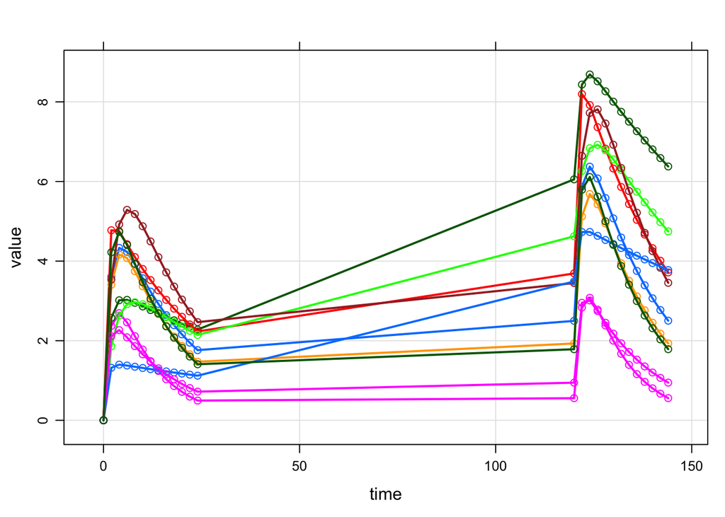

```r
mod %>%
  ev(amt=100, ii=24, addl = 9) %>%
  mrgsim(tgrid = des, nid = 10) %>%
  plot(DV~., type = 'b')
```

# 4 Assign unique end times to each ID

- Create an `idata_set` including each `ID` in the run
- column includes `end` … this will be the simulation end time

```r
idata <- data_frame(ID = 1:100)
idata <- mutate(idata, end = sample(c(1,2,3,4)*168, n(), replace = TRUE))
idata
```

```
. # A tibble: 100 x 2
.       ID   end
.    <int> <dbl>
.  1     1   672
.  2     2   672
.  3     3   504
.  4     4   336
.  5     5   336
.  6     6   504
.  7     7   168
.  8     8   504
.  9     9   672
. 10    10   168
. # ... with 90 more rows
```

Use `as_deslist` to create a list of designs …

- We look the column indicated by `descol` to understand how many different designs we need to make.
- By taking `descol = "end"`, there will be 4 different designs by virtue of the fact that we’ve got 4 different end times

```r
des <- as_deslist(idata, descol = "end")
des
```

```
. $end_168
. start:  0  end:    168  delta:  1  offset: 0  min:    0   max:    168
.
. $end_336
. start:  0  end:    336  delta:  1  offset: 0  min:    0   max:    336
.
. $end_504
. start:  0  end:    504  delta:  1  offset: 0  min:    0   max:    504
.
. $end_672
. start:  0  end:    672  delta:  1  offset: 0  min:    0   max:    672
.
. attr(,"descol")
. [1] "end"
```

What whould have happened if `descol = "ID"`?

Now, simulate with that design list

```r
out <-
  mod %>%
  idata_set(idata) %>%
  ev(amt=100, ii=24, addl = 28) %>%
  design(des) %>%
  mrgsim(carry.out = "end")
```

It is required that we

1. implement an `idata_set` … that is where the information is coming from and
2. identify the `idata_set` prior to identifying the `deslist`

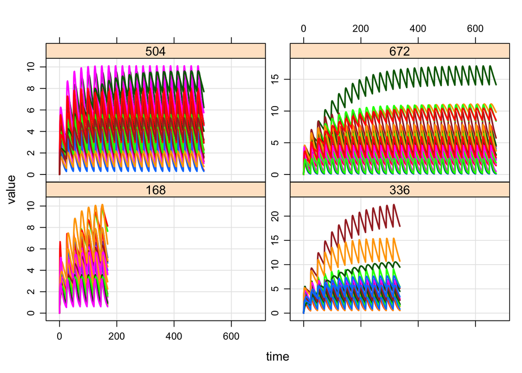

```r
plot(out, DV~time|factor(end))
```

What if we wanted less intense samples in the 2, 3, 4 week designs but not the 1 week design?